# Week 2

Yishak Ali

Go to https://registrar.fas.harvard.edu/faculty-staff/courses/enrollment and scroll down to “Access the Current Course Enrollment Numbers.” Click on that to download the Excel file. Create a folder in your project called `raw_data`. Move the Excel file into that folder. Be cool and do these things from the command line!

Load **tidyverse**, **readxl** and **janitor** into your setup chunk. You may need to install the packages **readxl** and **janitor** if you haven’t already.

### Scene 1

**Prompt:** Use **readxl** to read in the data and store it in an object called `raw`. Clean the data by cleaning any column names, skipping or cutting rows, and storing the cleaned data in an object called `en_fall_2020`. Additionally, since we will be looking only at undergraduate enrollment, get rid of any irrelevant columns, and filter to keep only courses with at least ten undergraduate students. This will get rid of any weird research courses. Look closely at your data! There is a lot of garbage to find and deal with.

Once you have finished cleaning your data, figure out the course with the highest enrollment. And figure out how many students are enrolled in Gov 50. If you get a number much lower than 151, you have done something wrong . . .

```r
raw <- read_excel("raw_data/class_enrollment_summary_by_term_9-17-2020.xlsx", skip = 3)

en_fall_2020 <- raw %>%
  clean_names() %>%
  select(u_grad, course_name, total, course_title, course_department) %>%
  filter(u_grad > 10) %>%
  arrange(desc(u_grad))
en_fall_2020
```

```
## # A tibble: 488 x 5
##    u_grad course_name               total course_title course_department
##     <dbl> <chr>                     <dbl> <chr>        <chr>
##  1  21541 <NA>                      33205 <NA>         <NA>
##  2    559 Principles of Economics     567 ECON 10A     Economics
##  3    504 Intro to Computer Science   547 COMPSCI 50   Computer Science
##  4    433 Introduction to Probabil…   480 STAT 110     Statistics
##  5    270 Intro. to Psychol. Scien…   282 PSY 1        Psychology
##  6    262 Intermediate Microeconom…   269 ECON 1010A   Economics
##  7    253 Stories from End of World   253 GENED 1001   General Education
##  8    253 Calculus, Series, and       254 MATH 1B      Mathematics
##  9    230 Justice: Ethics in Pande…   249 GENED 1171   General Education
## 10    225 Intro to Life Sciences I    225 LIFESCI 1A   Molecular & Cellular Bio…
## # … with 478 more rows
```

```r
subset(en_fall_2020, en_fall_2020$course_title == "GOV 50")
```

```
## # A tibble: 2 x 5
##   u_grad course_name total course_title course_department
##    <dbl> <chr>       <dbl> <chr>        <chr>
## 1    110 Data          112 GOV 50       Government
## 2     41 Data           45 GOV 50       Government
```

### Scene 2

**Prompt:** Create a bar plot of the 10 biggest courses. Order the plot so that courses appear in descending order. You will want to use coord_flip() to make your plot easy to read.

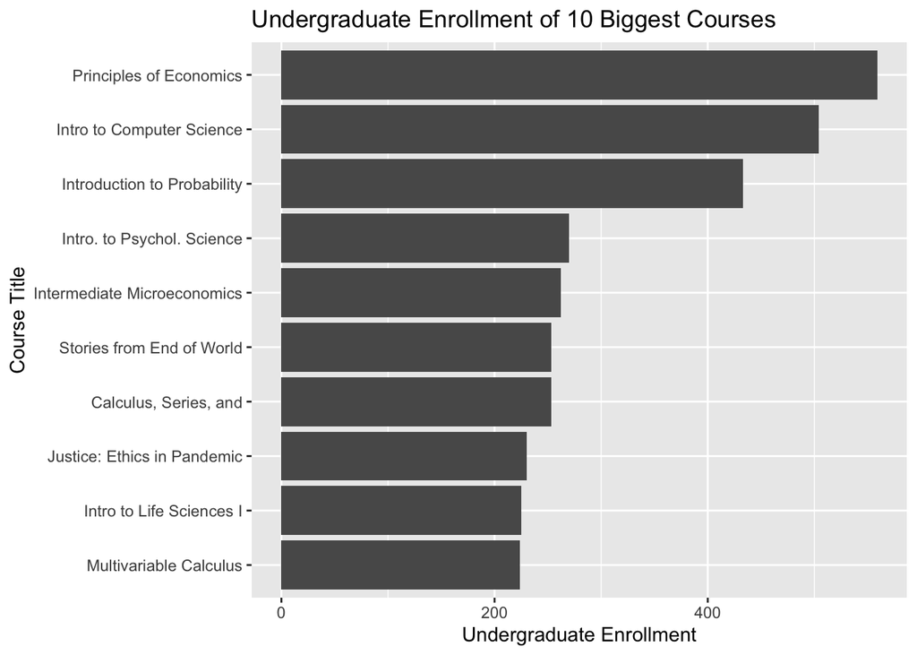

```r
en_fall_2020 %>%
  slice(2:11) %>%
  ggplot(aes(x = fct_reorder(course_name, u_grad), y = u_grad)) + geom_col() +
  coord_flip() + labs(title = "Undergraduate Enrollment of 10 Biggest Courses",
                      y = "Undergraduate Enrollment",
                      x = "Course Title")
```

### Scene 3

**Prompt:** Make a bar plot of total enrollment by department for the ten smallest departments. Arrange the bar plot in ascending order.

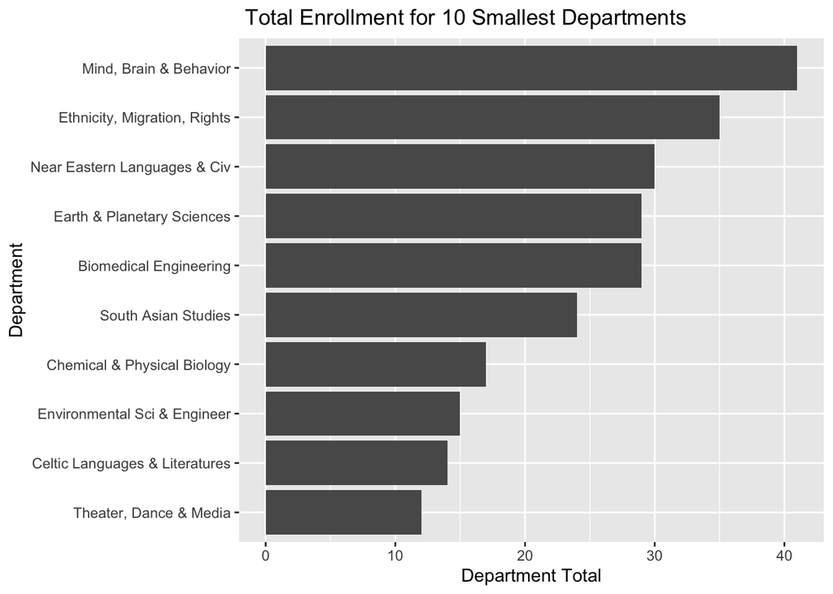

```r
en_fall_2020 %>%
  group_by(course_department) %>%
  summarize(department_total = sum(total)) %>%
  arrange(department_total) %>%
  slice(1:10) %>%
  ggplot(aes(x = fct_reorder(course_department, department_total), y = department_total)) +
    geom_col() +
    labs(title = " Total Enrollment for 10 Smallest Departments",
         y = "Department Total", x = "Department") +
    coord_flip()
```

### Scene 4

**Prompt:** Create a scatterplot of the length of course name versus enrollment for the Computer Science and Economics Department. Use `nchar()` to find the length, and include spaces. Add a linear line of best fit on your plot and scale axes appropriately.

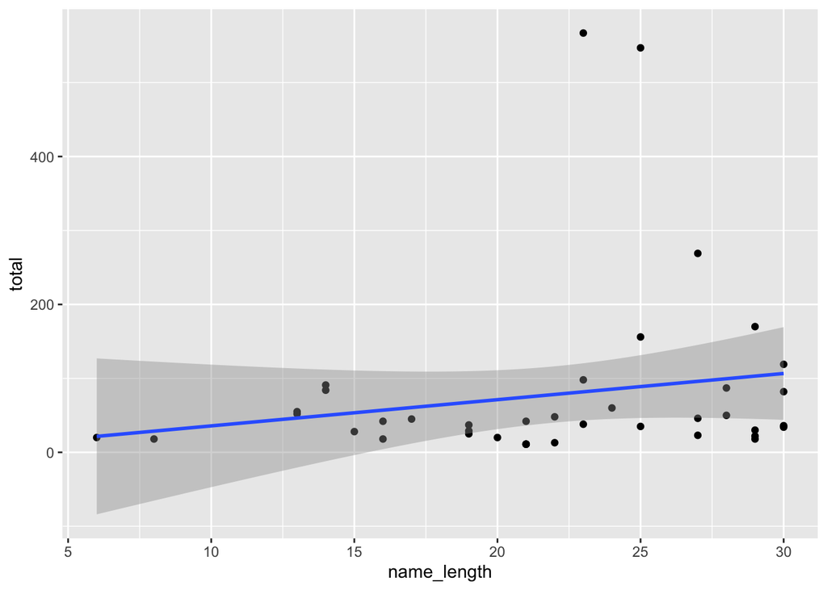

```r
en_fall_2020 %>%
  filter(course_department %in% c('Economics', 'Computer Science')) %>%
  mutate(name_length = nchar(course_name)) %>%
  ggplot(aes(x = name_length, y = total)) +
    geom_point() + geom_smooth(method = lm)
```